# Machine Learning for Problem Solving HW1

Anurag Gandhi

February 23, 2017

## 4.1 Exploratory Data Analysis

### Importing data

```r
termination = read.csv('termination.csv')
```

### 4.1 A. Summary

```r
kable(head(termination))
```

| EmployeeID | recorddate_key | birthdate_key | orighiredate_key | terminationdate_key | age | length_of_service | city_name | department_name | job_title | store_name | gender_short | gender_full | termreason_desc | termtype_desc | STATUS_YEAR | STATUS | BUSINESS_UNIT |
| --- | --- | --- | --- | --- | --- | --- | --- | --- | --- | --- | --- | --- | --- | --- | --- | --- | --- |
| 1318 | 12/31/2006 0:00 | 1954-01-03 | 1989-08-28 | 1900-01-01 | 52 | 17 | Vancouver | Executive | CEO | 35 | M | Male | Not Applicable | Not Applicable | 2006 | ACTIVE | HEADOFFICE |
| 1318 | 12/31/2007 0:00 | 1954-01-03 | 1989-08-28 | 1900-01-01 | 53 | 18 | Vancouver | Executive | CEO | 35 | M | Male | Not Applicable | Not Applicable | 2007 | ACTIVE | HEADOFFICE |
| 1318 | 12/31/2008 0:00 | 1954-01-03 | 1989-08-28 | 1900-01-01 | 54 | 19 | Vancouver | Executive | CEO | 35 | M | Male | Not Applicable | Not Applicable | 2008 | ACTIVE | HEADOFFICE |
| 1318 | 12/31/2009 0:00 | 1954-01-03 | 1989-08-28 | 1900-01-01 | 55 | 20 | Vancouver | Executive | CEO | 35 | M | Male | Not Applicable | Not Applicable | 2009 | ACTIVE | HEADOFFICE |
| 1318 | 12/31/2010 0:00 | 1954-01-03 | 1989-08-28 | 1900-01-01 | 56 | 21 | Vancouver | Executive | CEO | 35 | M | Male | Not Applicable | Not Applicable | 2010 | ACTIVE | HEADOFFICE |
| 1318 | 12/31/2011 0:00 | 1954-01-03 | 1989-08-28 | 1900-01-01 | 57 | 22 | Vancouver | Executive | CEO | 35 | M | Male | Not Applicable | Not Applicable | 2011 | ACTIVE | HEADOFFICE |

```r
summary(termination)
```

```
##    EmployeeID           recorddate_key     birthdate_key
##  Min.   :1318   12/31/2013 0:00: 5215   1954-08-04:   40
##  1st Qu.:3360   12/31/2012 0:00: 5101   1956-04-27:   40
##  Median :5031   12/31/2011 0:00: 4972   1973-03-23:   40
##  Mean   :4859   12/31/2014 0:00: 4962   1952-01-27:   30
##  3rd Qu.:6335   12/31/2010 0:00: 4840   1952-08-10:   30
##  Max.   :8336   12/31/2015 0:00: 4799   1953-10-06:   30
##                 (Other)        :19764   (Other)   :49443
##    orighiredate_key terminationdate_key      age        length_of_service
##  1992-08-09:   50   1900-01-01:42450    Min.   :19.00   Min.   : 0.00
##  1995-02-22:   50   2014-12-30: 1079    1st Qu.:31.00   1st Qu.: 5.00
##  2004-12-04:   50   2015-12-30:  674    Median :42.00   Median :10.00
##  2005-10-16:   50   2010-12-30:   25    Mean   :42.08   Mean   :10.43
##  2006-02-26:   50   2012-11-11:   21    3rd Qu.:53.00   3rd Qu.:15.00
##  2006-09-25:   50   2015-02-04:   20    Max.   :65.00   Max.   :26.00
##  (Other)   :49353   (Other)   : 5384
##            city_name             department_name          job_title
##  Vancouver      :11211   Meats           :10269   Meat Cutter  :9984
##  Victoria       : 4885   Dairy           : 8599   Dairy Person :8590
##  Nanaimo        : 3876   Produce         : 8515   Produce Clerk:8237
##  New Westminster: 3211   Bakery          : 8381   Baker        :8096
##  Kelowna        : 2513   Customer Service: 7122   Cashier      :6816
##  Burnaby        : 2067   Processed Foods : 5911   Shelf Stocker:5622
##  (Other)        :21890   (Other)         :  856   (Other)      :2308
##    store_name   gender_short gender_full          termreason_desc
##  Min.   : 1.0   F:25898      Female:25898   Layoff        : 1705
##  1st Qu.:16.0   M:23755      Male  :23755   Not Applicable:41853
##  Median :28.0                               Resignaton    : 2111
##  Mean   :27.3                               Retirement    : 3984
##  3rd Qu.:42.0
##  Max.   :46.0
##
##         termtype_desc    STATUS_YEAR          STATUS
##  Involuntary   : 1705   Min.   :2006   ACTIVE    :48168
##  Not Applicable:41853   1st Qu.:2008   TERMINATED: 1485
##  Voluntary     : 6095   Median :2011
##                         Mean   :2011
##                         3rd Qu.:2013
##                         Max.   :2015
##
##     BUSINESS_UNIT
##  HEADOFFICE:  585
##  STORES    :49068
##
##
##
##
##
```

#### Data Quality issues:

For evaluating data quality, I check for the following:

- **Correctness:**

Visually inspecting the descriptive statics shows that most of the variables seem correct. For example, Employee ID’s are all 4-digit numbers, distribution of age makes sence, genders have almost equal distribution etc.

- **Coherence:**

Some of the issues I found were:

**terminationdate_key:** This column has unusually large number of data points with value ‘1900-01-01’. I belive these would be the current employees.

**store_name**: The variable name says store name but these look more like store IDs.

- **3. Completeness:**

To check completeness, we need to count missing values for all variables.

```r
sapply(termination, function(x) sum(is.na(x)))
```

```
##          EmployeeID      recorddate_key       birthdate_key
##                   0                   0                   0
##    orighiredate_key terminationdate_key                 age
##                   0                   0                   0
##   length_of_service           city_name     department_name
##                   0                   0                   0
##           job_title          store_name        gender_short
##                   0                   0                   0
##         gender_full     termreason_desc       termtype_desc
##                   0                   0                   0
##         STATUS_YEAR              STATUS       BUSINESS_UNIT
##                   0                   0                   0
```

There are NO missing values for any of the variable. So, the data is complete.

### 4.1 B.

#### Percentage of terminated empployees for each year:

```r
subset <- select(termination, STATUS, STATUS_YEAR)
grouped <- group_by(subset, STATUS_YEAR, STATUS)
counts <- data.frame(summarize(grouped, Employees=n()))

counts <- reshape(counts, timevar = "STATUS", idvar = c("STATUS_YEAR"), times = "Employees", direction = "wide")
counts$PercTerminated <- counts$Employees.TERMINATED/(counts$Employees.ACTIVE + counts$Employees.TERMINATED)
avg_termination_rate <- mean(counts$PercTerminated)

counts$PercTerminated <- paste(round(counts$PercTerminated*100, 2), "%", sep="")

kable(counts)
```

|  | STATUS_YEAR | Employees.ACTIVE | Employees.TERMINATED | PercTerminated |
| --- | --- | --- | --- | --- |
| 1 | 2006 | 4445 | 134 | 2.93% |
| 3 | 2007 | 4521 | 162 | 3.46% |
| 5 | 2008 | 4603 | 164 | 3.44% |
| 7 | 2009 | 4710 | 142 | 2.93% |
| 9 | 2010 | 4840 | 123 | 2.48% |
| 11 | 2011 | 4972 | 110 | 2.16% |
| 13 | 2012 | 5101 | 130 | 2.49% |
| 15 | 2013 | 5215 | 105 | 1.97% |
| 17 | 2014 | 4962 | 253 | 4.85% |
| 19 | 2015 | 4799 | 162 | 3.27% |

> Average termination rate over the 10 years is 3%.

### 4.1 C.

#### Stacked bar plot of terminates by status year:

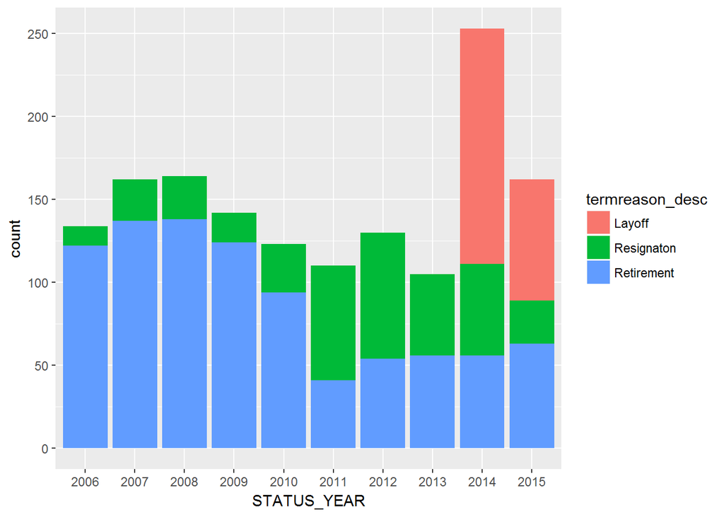

```r
terminated <- select(subset(termination, STATUS == "TERMINATED"), STATUS_YEAR, termreason_desc)
grouped <- group_by(terminated, STATUS_YEAR, termreason_desc)
grouped$STATUS_YEAR <- as.factor(grouped$STATUS_YEAR)
ggplot(data = grouped, aes(x = STATUS_YEAR, fill = termreason_desc)) + geom_bar()
```

#### Observations:

- Layoffs only happened in 2014 and 2015, and they form largest proportion of terminations in these years.
- Resignations have increased considerably over the years from 2006 to 2012, and have started to decrease again in 2015
- Overall, retirements have decreased, with minimum in year 2011

### 4.1 D.

#### Kernel Density plots:

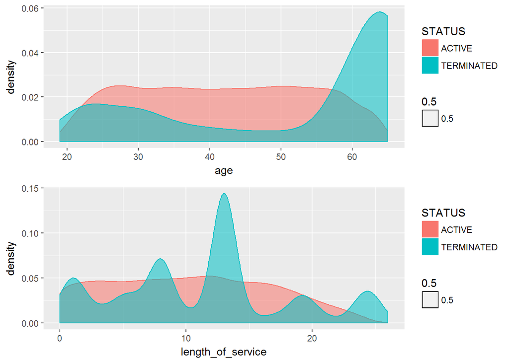

```r
age_data <- select(termination, age, STATUS)
los_data <- select(termination, length_of_service, STATUS)

age_plot <- ggplot(data = age_data, aes(x=age)) + geom_density(aes(group=STATUS, color=STATUS, fill=STATUS, alpha = 0.5))
los_plot <- ggplot(data = los_data, aes(x=length_of_service)) + geom_density(aes(group=STATUS, color=STATUS, fill=STATUS, alpha = 0.5))

grid.arrange(age_plot, los_plot)
```

> **Age**: From the above plots, we can observe that for active employees, age distribution is almost flat with less active employees around retirement age. But for terminated employees, a large number of employees were terminated after the age of 55. There are also less number of employees terminated for ages 35-50

> **Length of service**: Beyond 18-20 years of length of service, active employees decrease. But the trend for terminated employees has no such pattern. It seems that they can be terminated during any length of service.

#### Box-plots:

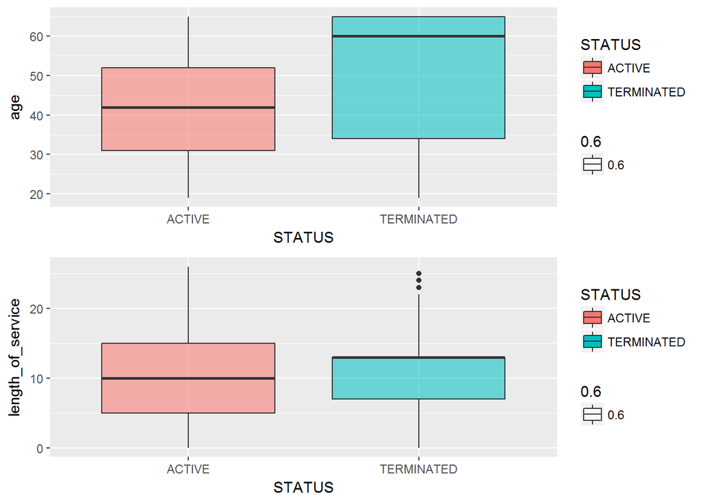

```r
age_plot2 <- ggplot(data = age_data, aes(x=STATUS, y = age, alpha = 0.6)) +geom_boxplot(aes(fill = STATUS))
los_plot2 <- ggplot(data = los_data, aes(x=STATUS, y = length_of_service, alpha = 0.6)) +geom_boxplot(aes(fill = STATUS))
grid.arrange(age_plot2, los_plot2)
```

> Box plots show similar pattern. Terminated employees seem more in number for ages above 50. Length of service does not seem to have an impact on termination status.

## 4.2 Classification Logistic Regression

### Importing data

```r
term_train <- read.csv('term_train.csv')
term_test <- read.csv('term_test.csv')
```

### 4.2 A.

#### Logistic Regression Model Summary

```r
term_train$STATUS_CODE <- ifelse(term_train$STATUS == "ACTIVE", 0, 1)

logit_term <- glm(STATUS_CODE ~ age + length_of_service + STATUS_YEAR + BUSINESS_UNIT, data = term_train,  family = binomial(link = 'logit'))
summary(logit_term)
```

```
##
## Call:
## glm(formula = STATUS_CODE ~ age + length_of_service + STATUS_YEAR +
##     BUSINESS_UNIT, family = binomial(link = "logit"), data = term_train)
##
## Deviance Residuals:
##     Min       1Q   Median       3Q      Max
## -1.3361  -0.2211  -0.1675  -0.1251   3.2870
##
## Coefficients:
##                       Estimate Std. Error z value Pr(>|z|)
## (Intercept)         -8.291e+02  3.448e+01  -24.04   <2e-16 ***
## age                  2.082e-01  4.607e-03   45.18   <2e-16 ***
## length_of_service   -4.016e-01  1.140e-02  -35.22   <2e-16 ***
## STATUS_YEAR          4.092e-01  1.713e-02   23.89   <2e-16 ***
## BUSINESS_UNITSTORES -2.450e+00  1.812e-01  -13.52   <2e-16 ***
## ---
## Signif. codes:  0 '***' 0.001 '**' 0.01 '*' 0.05 '.' 0.1 ' ' 1
##
## (Dispersion parameter for binomial family taken to be 1)
##
##     Null deviance: 9999.4  on 37238  degrees of freedom
## Residual deviance: 7856.0  on 37234  degrees of freedom
## AIC: 7866
##
## Number of Fisher Scoring iterations: 7
```

#### Predictions based on threshold = 0.5

```r
term_test$STATUS_CODE <- ifelse(term_test$STATUS == "ACTIVE", 0, 1)
term_test$predicted_prob <- predict(logit_term, newdata=term_test, type = "response")
term_test$predicted_STATUS <- ifelse(term_test$predicted_prob < 0.5, "ACTIVE", "TERMINATED")
```

#### Precision and recall

```r
true_positive <- sum((term_test$predicted_STATUS == 'TERMINATED') & (term_test$STATUS == term_test$predicted_STATUS))

false_positive <- sum(term_test$predicted_STATUS == "TERMINATED" & term_test$STATUS != term_test$predicted_STATUS)
true_negative <- sum(term_test$predicted_STATUS == "ACTIVE" & term_test$STATUS == term_test$predicted_STATUS)
false_negative <- sum(term_test$predicted_STATUS == "ACTIVE" & term_test$STATUS != term_test$predicted_STATUS)

precision <- true_positive/(true_positive + false_positive)
recall <- true_positive/(true_positive + false_negative)
```

> Precision Rate = 0.5428571 Recall Rate = 0.0509383

### 4.2 B

#### ROC Curve and AUC:

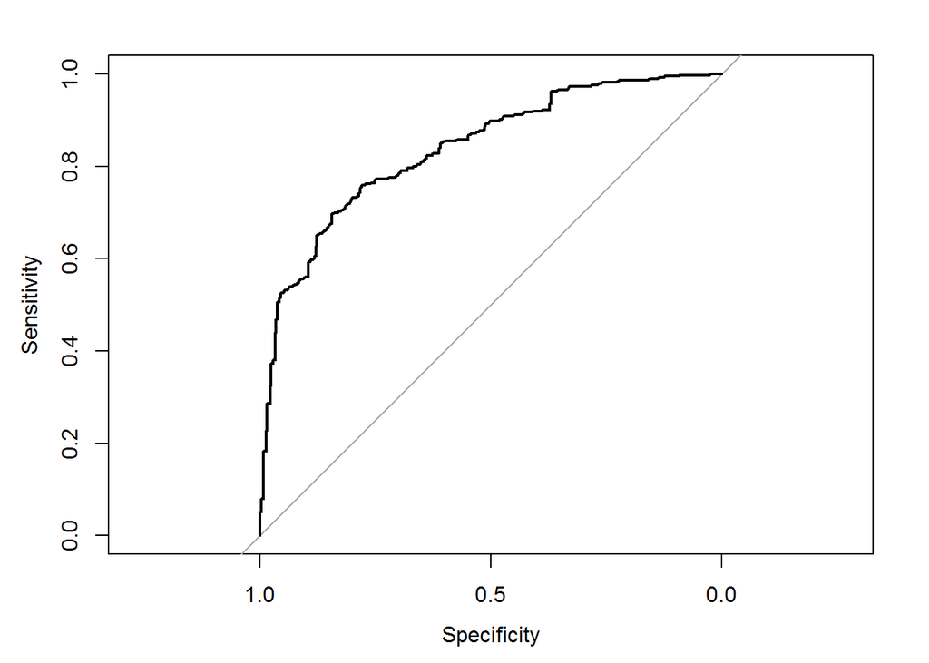

```r
roc_curve <- roc(STATUS ~ predicted_prob, data = term_test, auc=TRUE)
plot(roc_curve)
```

```r
pROC::auc(roc_curve)
```

```
## Area under the curve: 0.8377
```

## 5 Applied: Linear Regression

```r
attach(Wage)
```

### 5 A.

Regressing `Wage` on `Age`:

```r
wage_model <- lm(wage ~ age)
print(summary(wage_model))
```

```
##
## Call:
## lm(formula = wage ~ age)
##
## Residuals:
##      Min       1Q   Median       3Q      Max
## -100.265  -25.115   -6.063   16.601  205.748
##
## Coefficients:
##             Estimate Std. Error t value Pr(>|t|)
## (Intercept) 81.70474    2.84624   28.71   <2e-16 ***
## age          0.70728    0.06475   10.92   <2e-16 ***
## ---
## Signif. codes:  0 '***' 0.001 '**' 0.01 '*' 0.05 '.' 0.1 ' ' 1
##
## Residual standard error: 40.93 on 2998 degrees of freedom
## Multiple R-squared:  0.03827,    Adjusted R-squared:  0.03795
## F-statistic: 119.3 on 1 and 2998 DF,  p-value: < 2.2e-16
```

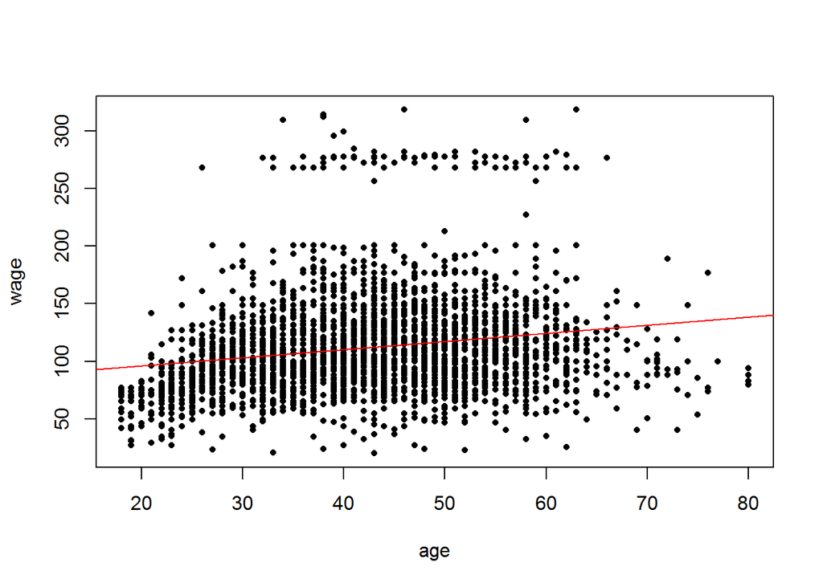

```r
plot(wage ~ age, cex=0.7, col = "black", pch=16)
abline(wage_model, col='red')
```

### 5 B.

Interaction model of `Wage` on `Age` and `jobclass`:

```r
wage_lm_interact <- lm(wage ~ age + jobclass + age*jobclass)
summary(wage_lm_interact)
```

```
##
## Call:
## lm(formula = wage ~ age + jobclass + age * jobclass)
##
## Residuals:
##      Min       1Q   Median       3Q      Max
## -105.656  -24.568   -6.104   16.433  196.810
##
## Coefficients:
##                            Estimate Std. Error t value Pr(>|t|)
## (Intercept)                73.52831    3.76133  19.548  < 2e-16 ***
## age                         0.71966    0.08744   8.230 2.75e-16 ***
## jobclass2. Information     22.73086    5.63141   4.036 5.56e-05 ***
## age:jobclass2. Information -0.16017    0.12785  -1.253     0.21
## ---
## Signif. codes:  0 '***' 0.001 '**' 0.01 '*' 0.05 '.' 0.1 ' ' 1
##
## Residual standard error: 40.16 on 2996 degrees of freedom
## Multiple R-squared:  0.07483,    Adjusted R-squared:  0.07391
## F-statistic: 80.78 on 3 and 2996 DF,  p-value: < 2.2e-16
```

#### Interpretation:

> Looking at the coefficient of age (0.72), we can say that on an average among people with jobclass = Industrial, every one year increase in age is associated with 0.72 increase in wage.

### 5 C.

```r
poly_wage_lm <- lm(wage ~ poly(age, 4, raw=T))
summary(poly_wage_lm)
```

```
##
## Call:
## lm(formula = wage ~ poly(age, 4, raw = T))
##
## Residuals:
##     Min      1Q  Median      3Q     Max
## -98.707 -24.626  -4.993  15.217 203.693
##
## Coefficients:
##                          Estimate Std. Error t value Pr(>|t|)
## (Intercept)            -1.842e+02  6.004e+01  -3.067 0.002180 **
## poly(age, 4, raw = T)1  2.125e+01  5.887e+00   3.609 0.000312 ***
## poly(age, 4, raw = T)2 -5.639e-01  2.061e-01  -2.736 0.006261 **
## poly(age, 4, raw = T)3  6.811e-03  3.066e-03   2.221 0.026398 *
## poly(age, 4, raw = T)4 -3.204e-05  1.641e-05  -1.952 0.051039 .
## ---
## Signif. codes:  0 '***' 0.001 '**' 0.01 '*' 0.05 '.' 0.1 ' ' 1
##
## Residual standard error: 39.91 on 2995 degrees of freedom
## Multiple R-squared:  0.08626,    Adjusted R-squared:  0.08504
## F-statistic: 70.69 on 4 and 2995 DF,  p-value: < 2.2e-16
```

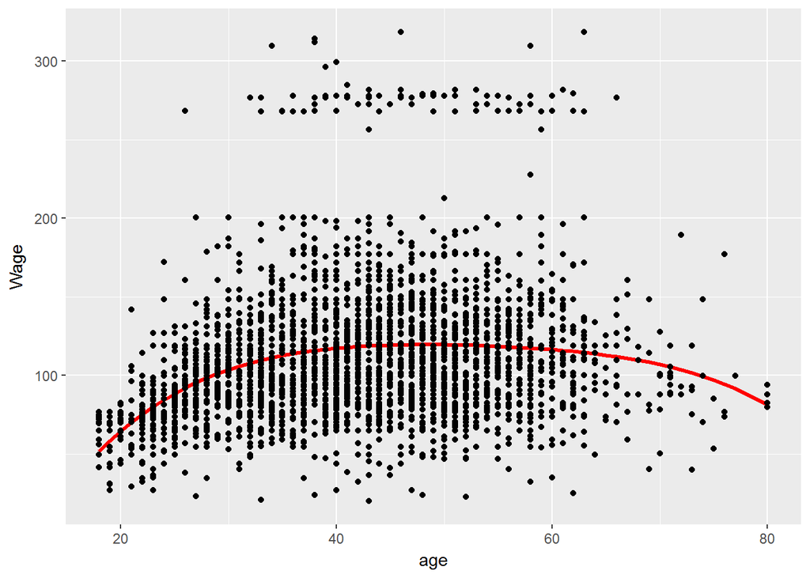

```r
predicted <- predict(poly_wage_lm)

ggplot(data=Wage,aes(x=age, y=predicted)) + geom_line(color='red', size=1.2) + geom_point(aes(x=age, y=wage)) +ylab('Wage')
```

> From the plot we can observe that adding non-linear polynomial features to the model helps fit the data better.

### 5 D.

Summary of Regression on all variables and their interactions:

```r
#Keeping only relavant columns
wage_subset <- subset(Wage,select = c(wage, year, age, maritl, race, education, jobclass, health, health_ins))

# Regressing on all variables and interactions
wage_lm_all <- lm(wage ~ year + age + maritl + race + education + jobclass + health + health_ins + .*., data = wage_subset)
summary(wage_lm_all)
```

```
##
## Call:
## lm(formula = wage ~ year + age + maritl + race + education +
##     jobclass + health + health_ins + . * ., data = wage_subset)
##
## Residuals:
##      Min       1Q   Median       3Q      Max
## -104.721  -18.495   -3.484   13.452  211.033
##
## Coefficients: (1 not defined because of singularities)
##                                                      Estimate Std. Error
## (Intercept)                                        -7.754e+03  3.528e+03
## year                                                3.906e+00  1.759e+00
## age                                                 1.052e+02  6.210e+01
## maritl2. Married                                   -1.955e+03  1.719e+03
## maritl3. Widowed                                   -2.404e+03  2.239e+04
## maritl4. Divorced                                  -1.577e+03  2.968e+03
## maritl5. Separated                                 -1.239e+03  4.965e+03
## race2. Black                                       -4.469e+02  2.264e+03
## race3. Asian                                        5.306e+03  2.508e+03
## race4. Other                                        4.704e+03  6.005e+03
## education2. HS Grad                                -1.941e+02  2.341e+03
## education3. Some College                            1.358e+03  2.506e+03
## education4. College Grad                            1.470e+03  2.517e+03
## education5. Advanced Degree                        -2.806e+03  2.766e+03
## jobclass2. Information                             -9.180e+02  1.328e+03
## health2. >=Very Good                                1.951e+03  1.441e+03
## health_ins2. No                                     2.117e+03  1.398e+03
## year:age                                           -5.246e-02  3.096e-02
## year:maritl2. Married                               9.868e-01  8.571e-01
## year:maritl3. Widowed                               1.178e+00  1.114e+01
## year:maritl4. Divorced                              8.014e-01  1.480e+00
## year:maritl5. Separated                             6.193e-01  2.475e+00
## year:race2. Black                                   2.253e-01  1.129e+00
## year:race3. Asian                                  -2.647e+00  1.251e+00
## year:race4. Other                                  -2.343e+00  2.993e+00
## year:education2. HS Grad                            9.788e-02  1.168e+00
## year:education3. Some College                      -6.810e-01  1.250e+00
## year:education4. College Grad                      -7.240e-01  1.256e+00
## year:education5. Advanced Degree                    1.401e+00  1.380e+00
```

[output cut: 207 more lines]

```
## education4. College Grad:health2. >=Very Good        0.651 0.515208
## education5. Advanced Degree:health2. >=Very Good     0.986 0.323980
## education2. HS Grad:health_ins2. No                 -0.102 0.918806
## education3. Some College:health_ins2. No             0.529 0.596921
## education4. College Grad:health_ins2. No            -1.971 0.048828 *
## education5. Advanced Degree:health_ins2. No         -1.497 0.134438
## jobclass2. Information:health2. >=Very Good         -0.004 0.996985
## jobclass2. Information:health_ins2. No              -0.343 0.731476
## health2. >=Very Good:health_ins2. No                 0.111 0.911545
## ---
## Signif. codes:  0 '***' 0.001 '**' 0.01 '*' 0.05 '.' 0.1 ' ' 1
##
## Residual standard error: 33.76 on 2879 degrees of freedom
## Multiple R-squared:  0.3717, Adjusted R-squared:  0.3455
## F-statistic: 14.19 on 120 and 2879 DF,  p-value: < 2.2e-16
```

### 5 E.

#### Lasso Regression:

Plot of lambda vs coefficients

```r
library(glmnet)
```

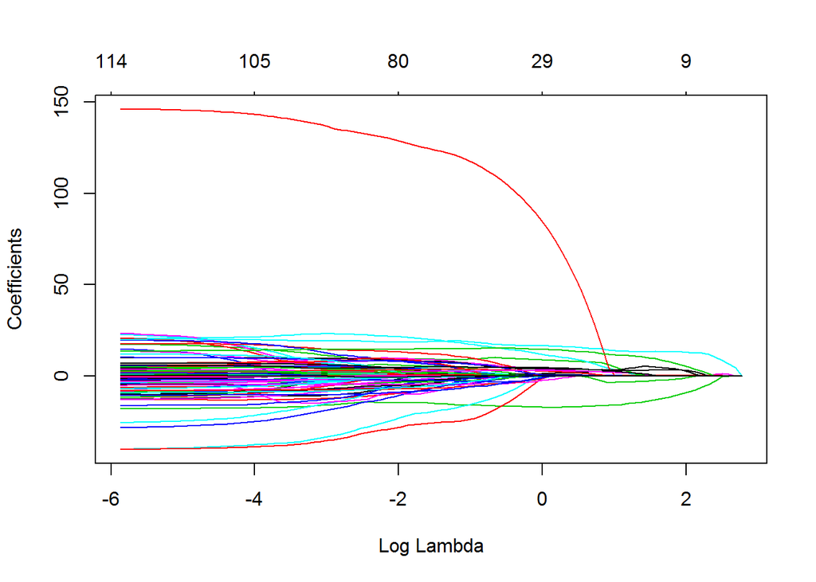

```r
x <- model.matrix(wage_lm_all, wage_subset)[,-1]
y <- wage_subset$wage

wage_lasso_ml <- glmnet(x, y, alpha=1)
plot(wage_lasso_ml, xvar="lambda")
```

We can observe that most of the coefficients approach **zero** for lambda > 0. This means we might be overfitting our data by adding so many features.

#### Grid search for optimum lambda

Plot of lambda vs cross validation error:

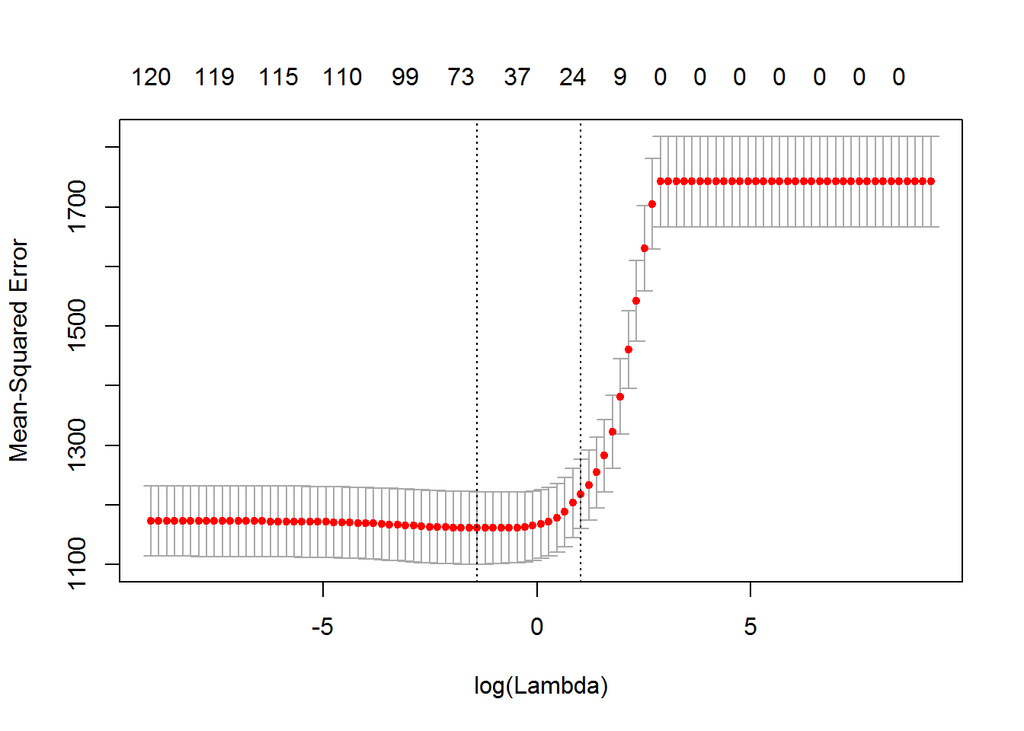

```r
# Define grid
grid=10^seq(4,-4, length =100)

# 10-fold cross validation
cv.error <- cv.glmnet(x, y, nfolds = 10, alpha=1, type.measure="mse", lambda=grid)

plot(cv.error)
```

To find the optimum lambda, we can either use `lambda.min` or `lambda.1se`. I prefer a simpler model with less coefficients, so I chose lambda such that error is within 1 se of minimum.

```r
optimum_lambda <- cv.error$lambda.1se
```

> Optimum lambda (1se) is 2.7825594

```r
error = cv.error$cvm[cv.error$lambda == optimum_lambda]
```

> Cross validation error for this lambda = 1218.327477

### 5 F.

Non linear regression with combination of natural splines and basis functions:

For age, this model will use a basis function with three knots - 20, 30 and 55. This is based on EDA we did earlier. Also, I will use natural splines with 4 degrees of freedom for year.

The summary of the model is:

```r
wage_non_linear <- glm(wage ~ bs(age, knots=c(20, 30, 55)) + ns(year, df=4) + education + race + health +
                         health_ins + jobclass + maritl, family = gaussian, data=Wage)



summary(wage_non_linear)
```

```
##
## Call:
## glm(formula = wage ~ bs(age, knots = c(20, 30, 55)) + ns(year,
##     df = 4) + education + race + health + health_ins + jobclass +
##     maritl, family = gaussian, data = Wage)
##
## Deviance Residuals:
##      Min        1Q    Median        3Q       Max
## -102.192   -18.652    -3.404    13.709   210.831
##
## Coefficients:
##                                  Estimate Std. Error t value Pr(>|t|)
## (Intercept)                      61.64090   10.39700   5.929 3.40e-09 ***
## bs(age, knots = c(20, 30, 55))1  -0.98583   12.85706  -0.077  0.93889
## bs(age, knots = c(20, 30, 55))2  -4.65284   10.69694  -0.435  0.66362
## bs(age, knots = c(20, 30, 55))3  22.94147   11.08306   2.070  0.03854 *
## bs(age, knots = c(20, 30, 55))4  17.68696   11.46112   1.543  0.12289
## bs(age, knots = c(20, 30, 55))5  14.96126   12.73922   1.174  0.24032
## bs(age, knots = c(20, 30, 55))6  -4.03270   16.29955  -0.247  0.80461
## ns(year, df = 4)1                 8.22473    3.33080   2.469  0.01359 *
## ns(year, df = 4)2                 3.98898    2.84323   1.403  0.16073
## ns(year, df = 4)3                 8.86301    4.04876   2.189  0.02867 *
## ns(year, df = 4)4                 7.23616    2.30519   3.139  0.00171 **
## education2. HS Grad               7.69403    2.36070   3.259  0.00113 **
## education3. Some College         18.20213    2.51339   7.242 5.60e-13 ***
## education4. College Grad         30.86024    2.54213  12.140  < 2e-16 ***
## education5. Advanced Degree      53.19222    2.79877  19.006  < 2e-16 ***
## race2. Black                     -4.92020    2.13571  -2.304  0.02130 *
## race3. Asian                     -2.64259    2.59017  -1.020  0.30770
## race4. Other                     -5.16275    5.63693  -0.916  0.35980
## health2. >=Very Good              6.36599    1.41337   4.504 6.92e-06 ***
## health_ins2. No                 -16.44398    1.40760 -11.682  < 2e-16 ***
## jobclass2. Information            3.40936    1.31685   2.589  0.00967 **
## maritl2. Married                 13.22601    1.81933   7.270 4.58e-13 ***
## maritl3. Widowed                  0.01844    7.97203   0.002  0.99816
## maritl4. Divorced                -0.03737    2.93256  -0.013  0.98983
## maritl5. Separated                7.18997    4.85584   1.481  0.13880
## ---
## Signif. codes:  0 '***' 0.001 '**' 0.01 '*' 0.05 '.' 0.1 ' ' 1
##
## (Dispersion parameter for gaussian family taken to be 1140.093)
##
##     Null deviance: 5222086  on 2999  degrees of freedom
## Residual deviance: 3391777  on 2975  degrees of freedom
## AIC: 29657
##
## Number of Fisher Scoring iterations: 2
```

#### 10-fold Cross validation error:

```r
cverror2 <- cv.glm(data=Wage, wage_non_linear, K=10)$delta[1]
print(cverror2)
```

```
## [1] 1148.727
```

> This cross validation error :1148.73 is less than the cross validation error with regularization and all interaction terms: 1218.33. We can further improve performance by combining elements from both regularization and non linear modelling, or using General Additive Models.